# S-109A Introduction to Data Science

[figure not shown]

## Homework 3 - Forecasting Bike Sharing Usage

**Harvard University**  
**Summer 2018**  
**Instructors**: Pavlos Protopapas, Kevin Rader

### INSTRUCTIONS

- To submit your assignment follow the instructions given in canvas.
- Restart the kernel and run the whole notebook again before you submit.
- If you submit individually and you have worked with someone, please include the name of your [one] partner below.

Names of people you have worked with goes here:

```python
from IPython.core.display import HTML
def css_styling(): styles = open("cs109.css", "r").read(); return HTML(styles)
css_styling()
```

[figure not shown]

Main Theme: Multiple Linear Regression, Subset Selection, Polynomial Regression

### Overview

You are hired by the administrators of the [Capital Bikeshare program](https://www.capitalbikeshare.com) program in Washington D.C., to **help them predict the hourly demand for rental bikes** and **give them suggestions on how to increase their revenue**. You will prepare a small report for them.

The hourly demand information would be useful in planning the number of bikes that need to be available in the system on any given hour of the day, and also in monitoring traffic in the city. It costs the program money if bike stations are full and bikes cannot be returned, or empty and there are no bikes available. You will use multiple linear regression and polynomial regression and will explore techniques for subset selection. The goal is to build a regression model that can predict the total number of bike rentals in a given hour of the day, based on attributes about the hour and the day.

An example of a suggestion to increase revenue might be to offer discounts during certain times of the day either during holidays or non-holidays. Your suggestions will depend on your observations of the seasonality of ridership.

The data for this problem were collected from the Capital Bikeshare program over the course of two years (2011 and 2012).

### Use only the libraries below:

```python
import numpy as np
import pandas as pd
import matplotlib
import matplotlib.pyplot as plt

import statsmodels.api as sm
from statsmodels.api import OLS

from sklearn import preprocessing
from sklearn.preprocessing import PolynomialFeatures
from sklearn.metrics import r2_score
from sklearn.model_selection import train_test_split
from sklearn.linear_model import LinearRegression

from pandas.plotting import scatter_matrix

import seaborn as sns


%matplotlib inline
```

## Data Exploration & Preprocessing, Multiple Linear Regression, Subset Selection

### Overview

The initial data set is provided in the file `data/BSS_hour_raw.csv`. You will add some features that will help us with the analysis and then separate it into training and test sets. Each row in this file contains 12 attributes and each entry represents one hour of a 24-hour day with its weather, etc, and the number of rental rides for that day divided in categories according to if they were made by registered or casual riders. Those attributes are the following:

- `dteday` (date in the format YYYY-MM-DD, e.g. 2011-01-01)
- `season` (1 = winter, 2 = spring, 3 = summer, 4 = fall)
- `hour` (0 for 12 midnight, 1 for 1:00am, 23 for 11:00pm)
- `weekday` (0 through 6, with 0 denoting Sunday)
- `holiday` (1 = the day is a holiday, 0 = otherwise)
- `weather`
  - 1: Clear, Few clouds, Partly cloudy, Partly cloudy
  - 2: Mist + Cloudy, Mist + Broken clouds, Mist + Few clouds, Mist
  - 3: Light Snow, Light Rain + Thunderstorm
  - 4: Heavy Rain + Thunderstorm + Mist, Snow + Fog
- `temp` (temperature in Celsius)
- `atemp` (apparent temperature, or relative outdoor temperature, in Celsius)
- `hum` (relative humidity)
- `windspeed` (wind speed)
- `casual` (number of rides that day made by casual riders, not registered in the system)
- `registered` (number of rides that day made by registered riders)

### General Hints

- Use pandas .describe() to see statistics for the dataset.
- When performing manipulations on column data it is useful and often more efficient to write a function and apply this function to the column as a whole without the need for iterating through the elements.
- A scatterplot matrix or correlation matrix are both good ways to see dependencies between multiple variables.
- For Question 2, a very useful pandas method is .groupby(). Make sure you aggregate the rest of the columns in a meaningful way. Print the dataframe to make sure all variables/columns are there!

### Resources

http://pandas.pydata.org/pandas-docs/stable/generated/pandas.to_datetime.html

**Question 1: Explore how Bike Ridership varies with Hour of the Day**

#### Learn your Domain and Perform a bit of Feature Engineering

**1.1** Load the dataset from the csv file `data/BSS_hour_raw.csv` into a pandas dataframe that you name `bikes_df`. Do any of the variables' ranges or averages seem suspect? Do the data types make sense?

**1.2** Notice that the variable in column `dteday` is a pandas `object`, which is **not** useful when you want to extract the elements of the date such as the year, month, and day. Convert `dteday` into a `datetime` object to prepare it for later analysis.

**1.3** Create three new columns in the dataframe:

- `year` with 0 for 2011 and 1 for 2012.
- `month` with 1 through 12, with 1 denoting Jan.
- `counts` with the total number of bike rentals for that day (this is the response variable for later).

**1.4** Use visualization to inspect and comment on how **casual** rentals and **registered** rentals vary with the `hour`.

**1.5** Use the variable `holiday` to show how **holidays** affect the relationship in question 1.4. What do you observe?

**1.6** Use visualization to show how **weather** affects **casual** and **registered** rentals. What do you observe?

### Answers

#### 1.1 Load the dataset from the csv file ...

```python
bikes_df = pd.read_csv("data/BSS_hour_raw.csv", index_col=0)
```

None of the variable ranges really seem suspect. The only one that seems a little confusing to me is hum. It seems weird that humidity can be so high during the winter time. For example, one in Jan says .81, which I'm guessing is 81%? Data types make sense to me.

Also, there is one issue with the temperature. It seems to only go between 0 and 1, but only in celcuis, so it must've been normalized?

#### 1.2 Notice that the variable in column ....

```python
pd.to_datetime(bikes_df.index)
```

```
DatetimeIndex(['2011-01-01', '2011-01-01', '2011-01-01', '2011-01-01',
               '2011-01-01', '2011-01-01', '2011-01-01', '2011-01-01',
               '2011-01-01', '2011-01-01',
               ...
               '2012-12-31', '2012-12-31', '2012-12-31', '2012-12-31',
               '2012-12-31', '2012-12-31', '2012-12-31', '2012-12-31',
               '2012-12-31', '2012-12-31'],
              dtype='datetime64[ns]', name='dteday', length=17379, freq=None)
```

#### 1.3 Create three new columns ...

```python
# add counts column

bikes_df['counts'] = bikes_df['casual'] + bikes_df['registered']

# add month column

bikes_df['month'] = pd.to_datetime(bikes_df.index).month

# add year column

bikes_df['years'] = pd.to_datetime(bikes_df.index).year

bikes_df["year"] = [0 if yr  == 2011 else 1 for yr in bikes_df["years"]]

# delete years column to leave just year

bikes_df = bikes_df.drop('years', axis=1)

bikes_df.head()
```

| dteday | season | hour | holiday | weekday | workingday | weather | temp | atemp | hum | windspeed | casual | registered | counts | month | year |
| --- | --- | --- | --- | --- | --- | --- | --- | --- | --- | --- | --- | --- | --- | --- | --- |
| 2011-01-01 | 1 | 0 | 0 | 6 | 0 | 1 | 0.24 | 0.2879 | 0.81 | 0.0 | 3 | 13 | 16 | 1 | 0 |
| 2011-01-01 | 1 | 1 | 0 | 6 | 0 | 1 | 0.22 | 0.2727 | 0.80 | 0.0 | 8 | 32 | 40 | 1 | 0 |
| 2011-01-01 | 1 | 2 | 0 | 6 | 0 | 1 | 0.22 | 0.2727 | 0.80 | 0.0 | 5 | 27 | 32 | 1 | 0 |
| 2011-01-01 | 1 | 3 | 0 | 6 | 0 | 1 | 0.24 | 0.2879 | 0.75 | 0.0 | 3 | 10 | 13 | 1 | 0 |
| 2011-01-01 | 1 | 4 | 0 | 6 | 0 | 1 | 0.24 | 0.2879 | 0.75 | 0.0 | 0 | 1 | 1 | 1 | 0 |

#### 1.4 Use visualization to inspect and comment on how casual rentals and registered rentals vary with the hour.

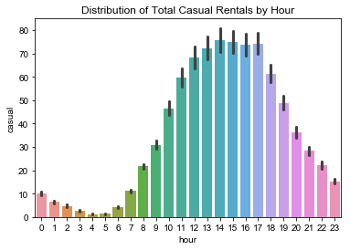

```python
plt.title("Distribution of Total Casual Rentals by Hour")
sns.set(style="whitegrid")
ax = sns.barplot(x="hour", y="casual", data=bikes_df)
```

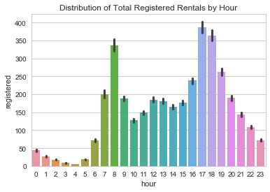

```python
plt.title("Distribution of Total Registered Rentals by Hour")
sns.set(style="whitegrid")
ax = sns.barplot(x="hour", y="registered", data=bikes_df)
```

Comparing the two graphs above, registered users tend to follow the typical work schedule. Whereas the casual users are less prevelant in the morning. They seem to be common during the second half of the day; maybe going to lunch/dinner/out and then coming back home or biking around the city.

#### 1.5 Use the variable holiday to show how holidays affect the relationship in question 1.4. What do you observe?

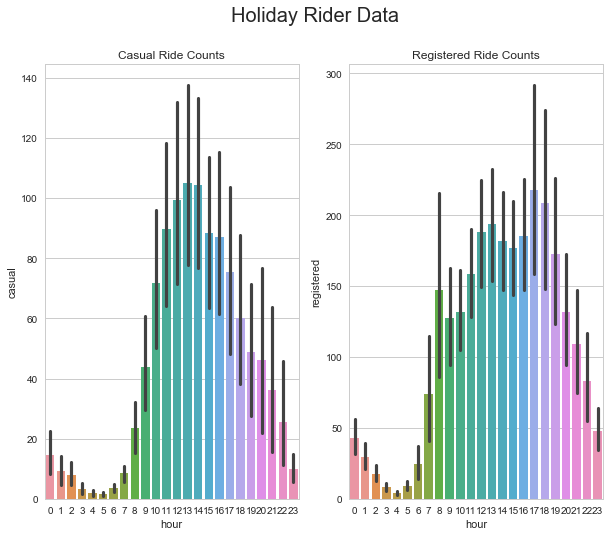

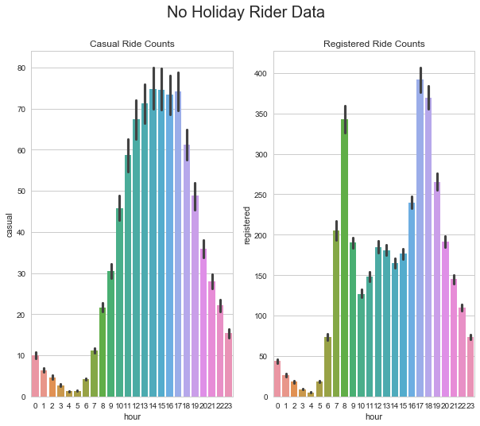

```python
#holiday (casual + registered)

holiday = bikes_df[(bikes_df['holiday'] == 1)]

fig, ax = plt.subplots(1, 2, figsize=(10,8))
sns.set(style="whitegrid")
sns.barplot(x="hour", y="casual", data=holiday, ax=ax[0])
ax[0].set_title('Casual Ride Counts')
ax[1].set_title('Registered Ride Counts')
sns.barplot(x="hour", y="registered", data=holiday,ax=ax[1])
fig.suptitle('Holiday Rider Data', fontsize=20);
fig.show()

#no holiday (casual + registered)

no_holiday = bikes_df[(bikes_df['holiday'] == 0)]

fig, ax = plt.subplots(1, 2, figsize=(10,8))
sns.set(style="whitegrid")
sns.barplot(x="hour", y="casual", data=no_holiday, ax=ax[0])
sns.barplot(x="hour", y="registered", data=no_holiday,ax=ax[1])
ax[0].set_title('Casual Ride Counts')
ax[1].set_title('Registered Ride Counts')
fig.suptitle('No Holiday Rider Data', fontsize=20);
fig.show()
```

Looking at the graphs above, we can observe a few trends. The first thing that stood out to me was that there was a higher overall rider count for registered users during not holiday days, whereas for the casual riders, it was the oppposite. There was a large spike in the rider count for casual users during the holidays. Less registered users are using the service during the holidays. During the work days, the registered riders follows the workday. There is spike for the commute to work and then around spike during after work; whereas for the casual rides, it is a consistent rider count for the second half of the day even though there is less people using it. Intutiviely, this makes sense. Registered rides tend to use the service more during workdays to get to work, whereas casual rider usage will increase during holidays because they need something to do.

#### 1.6 Use visualization to show how weather affects casual and registered rentals. What do you observe?

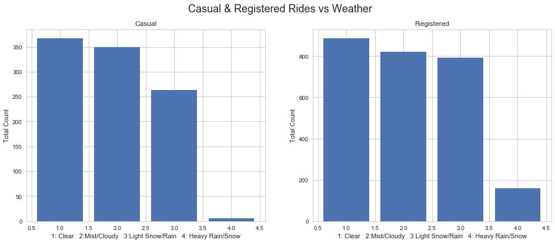

```python
# 1: clear/few clouds/cloudy
# 2: mist+cloud/mist+broken clouds/mist
# 3: light snow, light rain + thudnerstorm
# 4: heavy rain/thunder/snow+fog

f, (ax1, ax2) = plt.subplots(1, 2, figsize=(16,6))
ax1.bar(bikes_df['weather'], bikes_df['casual'])
ax1.set_xlabel("1: Clear   2:Mist/Cloudy   3:Light Snow/Rain   4: Heavy Rain/Snow")
ax2.set_xlabel("1: Clear   2:Mist/Cloudy   3:Light Snow/Rain   4: Heavy Rain/Snow")
ax1.set_ylabel("Total Count")
ax2.set_ylabel("Total Count")
ax1.set_title('Casual')
ax2.set_title('Registered')
ax2.bar(bikes_df['weather'], bikes_df['registered'])
f.suptitle('Casual & Registered Rides vs Weather', fontsize=18);
```

From looking at the two graphs above, both graphs exhibit a similar overall behaviour. As the weather gets worse (1 -> 4), there is less total rides. However, one important thing I noticed was that registered riders used the service more when the weather was poor; this makes sense because I would assume that people who use it everyday, tend to use it everyday. Another (obvious) obsevration is that casual users dont use the service when the weather is really bad out. This makes perfect sense. Overall, ride counts for the registered customers is significantly higher than casual in all weather conditions.

**Question 2: Explore Seasonality on Bike Ridership.**

#### Seasonality and weather

Now let's examine the effect of weather and time of the year. For example, you want to see how ridership varies with season of the year.

**2.1** Make a new dataframe with the following subset of attributes from the previous dataset and with each entry being **ONE** day:

- `dteday`, the timestamp for that day (fine to set to noon or any other time)
- `weekday`, the day of the week
- `weather`, the most severe weather that day
- `season`, the season that day falls in
- `temp`, the average temperature
- `atemp`, the average atemp that day
- `windspeed`, the average windspeed that day
- `hum`, the average humidity that day
- `casual`, the **total** number of rentals by casual users
- `registered`, the **total** number of rentals by registered users
- `counts`, the **total** number of rentals

Name this dataframe `bikes_by_day` and use it for all of Question 2.

**2.2** How does **season** affect the number of bike rentals for **casual riders** or **registered riders** per day? Use the variable `season` for this question. Comment on your observations.

**2.3** What percentage of rentals are made by casual riders or registered riders for each day of the week? Comment on any patterns you see and give a possible explanation.

**2.4** How is the **distribution of total number of bike rentals** different for sunny days vs cloudy days?

**2.5** Visualize how the **total number of rides** per day varies with the **season**. Do you see any **outliers**? (We define an outlier as a value 1.5 times the IQR above the 75th percentile or 1.5 times the IQR below the 25th percentiles. This is the same rule used by pyplot's boxplot function). If you see any outliers, identify those dates and investigate if they are a chance occurence, an error in the data collection, or an important event.

#### HINT

- Use .copy() when creating the new dataframe, so you leave the original untouched. We will come back to it later.
- Use .groupby() to creat the new dataframe. You will have to make some choice on how to aggregate the variables.

### Answers

#### 2.1 Make a new dataframe with the following subset ...

```python
df = bikes_df.copy()

df2 = df.groupby('dteday')
df2_mean = df2['weekday','season','temp','atemp','windspeed','hum'].agg(np.mean)
df2_max = df2['weather'].agg(np.max)
df2_count = df2['casual','registered'].agg(np.sum)

weekday = df2_mean['weekday']
weather = df2_max
season = df2_mean['season']
temp = df2_mean['temp']
atemp = df2_mean['atemp']
windspeed = df2_mean['windspeed']
hum = df2_mean['hum']
casual = df2_count['casual']
registered = df2_count['registered']
counts = casual + registered

rows = list(zip(df2_mean.index, weekday.values, weather.values, season.values, temp.values, atemp.values, \
          windspeed.values, hum.values, casual.values, registered.values, counts.values))

bikes_by_day = pd.DataFrame(rows, columns=['dteday','weekday','weather','season','temp','atemp', \
                            'windspeed','hum','casual','registered','counts'])

bikes_by_day.head()
```

|  | dteday | weekday | weather | season | temp | atemp | windspeed | hum | casual | registered | counts |
| --- | --- | --- | --- | --- | --- | --- | --- | --- | --- | --- | --- |
| 0 | 2011-01-01 | 6 | 3 | 1 | 0.344167 | 0.363625 | 0.160446 | 0.805833 | 331 | 654 | 985 |
| 1 | 2011-01-02 | 0 | 3 | 1 | 0.363478 | 0.353739 | 0.248539 | 0.696087 | 131 | 670 | 801 |
| 2 | 2011-01-03 | 1 | 1 | 1 | 0.196364 | 0.189405 | 0.248309 | 0.437273 | 120 | 1229 | 1349 |
| 3 | 2011-01-04 | 2 | 2 | 1 | 0.200000 | 0.212122 | 0.160296 | 0.590435 | 108 | 1454 | 1562 |
| 4 | 2011-01-05 | 3 | 1 | 1 | 0.226957 | 0.229270 | 0.186900 | 0.436957 | 82 | 1518 | 1600 |

#### 2.2 How does season affect the number of bike ...

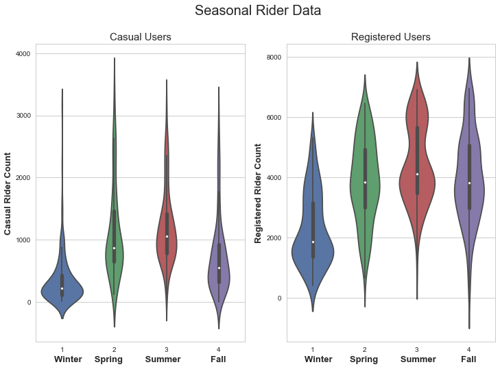

```python
# 1 = winter, 2 = spring, 3 = summer, 4 = fall

fig, ax = plt.subplots(1, 2, figsize=(12,8))
a = sns.violinplot(x="season", y="casual", data=bikes_by_day, ax=ax[0])
b = sns.violinplot(x="season", y="registered", data=bikes_by_day, ax=ax[1])
ax[0].set_title('Casual Users', fontsize=15)
ax[1].set_title('Registered Users', fontsize=15)
fig.suptitle('Seasonal Rider Data', fontsize=20);
a.set_xlabel('Winter     Spring         Summer            Fall', fontsize=13, fontweight='bold')
a.set_ylabel('Casual Rider Count', fontsize=13, fontweight='bold')
b.set_ylabel('Registered Rider Count', fontsize=13, fontweight='bold')
b.set_xlabel('Winter       Spring         Summer          Fall', fontsize=13, fontweight='bold')
fig.show()

# also: https://stackoverflow.com/questions/49065837/customize-the-axis-label-in-seaborn-jointplot
#resource used: https://stackoverflow.com/questions/43131274/how-do-i-plot-two-countplot-graphs-side-by-side-in-seaborn
```

#### 2.3 What percentage of rentals are made by casual riders or registered riders ...

```python
sun = bikes_by_day[(bikes_by_day['weekday'] == 0)]
sun1 = (sun['casual'].sum())/(sun['counts'].sum())*100
sun2 = 100 - sun1

mon = bikes_by_day[(bikes_by_day['weekday'] == 1)]
mon1 = (mon['casual'].sum())/(mon['counts'].sum())*100
mon2 = 100 - mon1

tues = bikes_by_day[(bikes_by_day['weekday'] == 2)]
tues1 = (tues['casual'].sum())/(tues['counts'].sum())*100
tues2 = 100 - tues1

wed = bikes_by_day[(bikes_by_day['weekday'] == 3)]
wed1 = (wed['casual'].sum())/(wed['counts'].sum())*100
wed2 = 100 - wed1

thurs = bikes_by_day[(bikes_by_day['weekday'] == 4)]
thurs1 = (thurs['casual'].sum())/(thurs['counts'].sum())*100
thurs2 = 100 - thurs1

fri = bikes_by_day[(bikes_by_day['weekday'] == 5)]
fri1 = (fri['casual'].sum())/(fri['counts'].sum())*100
fri2 = 100 - fri1

sat = bikes_by_day[(bikes_by_day['weekday'] == 6)]
sat1 = (fri['casual'].sum())/(sat['counts'].sum())*100
sat2 = 100 - sat1

day_of_week = ('Sunday', 'Monday', 'Tuesday', 'Wednesday', 'Thursday', 'Friday', 'Saturday')
casual = (sun1, mon1, tues1, wed1, thurs1, fri1, sat1)
reg = (sun2, mon2, tues2, wed2, thurs2, fri2, sat2)

percent = pd.DataFrame(list(zip(day_of_week, casual, reg)), columns=['Day of Week', 'casual', 'registered'])
percent['casual'] = percent['casual'].astype(str) + '%'
percent['registered'] = percent['registered'].astype(str) + '%'

percent
```

|  | Day of Week | casual | registered |
| --- | --- | --- | --- |
| 0 | Sunday | 31.64694939722134% | 68.35305060277867% |
| 1 | Monday | 15.539743975341548% | 84.46025602465845% |
| 2 | Tuesday | 12.330396560287694% | 87.6696034397123% |
| 3 | Wednesday | 12.116952190898175% | 87.88304780910183% |
| 4 | Thursday | 12.661852717889555% | 87.33814728211044% |
| 5 | Friday | 16.039279198015542% | 83.96072080198445% |
| 6 | Saturday | 16.374393845213653% | 83.62560615478634% |

#### 2.4 How is the distribution of total number of bike rentals different ...

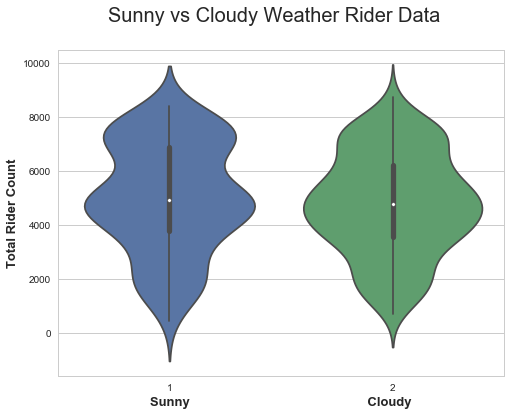

```python
# cloudy = 2, sunny = 1

sunny = bikes_by_day[(bikes_by_day['weather'] == 1)]

cloudy = bikes_by_day[(bikes_by_day['weather'] == 2)]

frames = [sunny, cloudy]

sunny_cloudy = pd.concat(frames)

fig, ax = plt.subplots(figsize=(8,6))
a = sns.violinplot(x="weather", y="counts", data=sunny_cloudy)
fig.suptitle('Sunny vs Cloudy Weather Rider Data', fontsize=20);
a.set_xlabel('Sunny                                                 Cloudy', fontsize=13, fontweight='bold')
a.set_ylabel('Total Rider Count', fontsize=13, fontweight='bold')
fig.show()
```

Looking at the violin plot above, it can be said that the distribution for the sunny days is different from the cloudy days. The distribtuion for the sunny days is "top heavy," which means that there are more days where riders took out the bikes during sunny days, versus the cloudy days, whhere the distrubition was lower. The means for both data sets is very similar, but the sunny total rider count mean is slightly higher. There were less cloudy days where a lot of people went out and used the bicycles.

#### 2.5 Visualize how the total number of rides per day ...

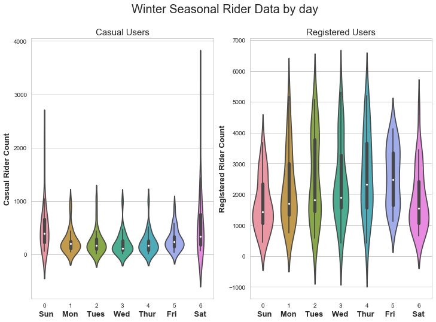

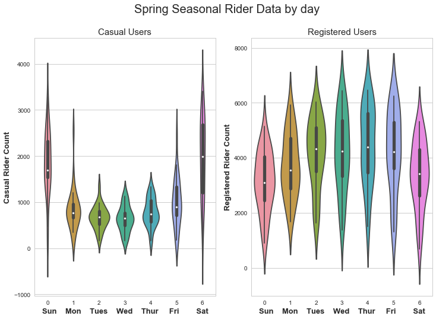

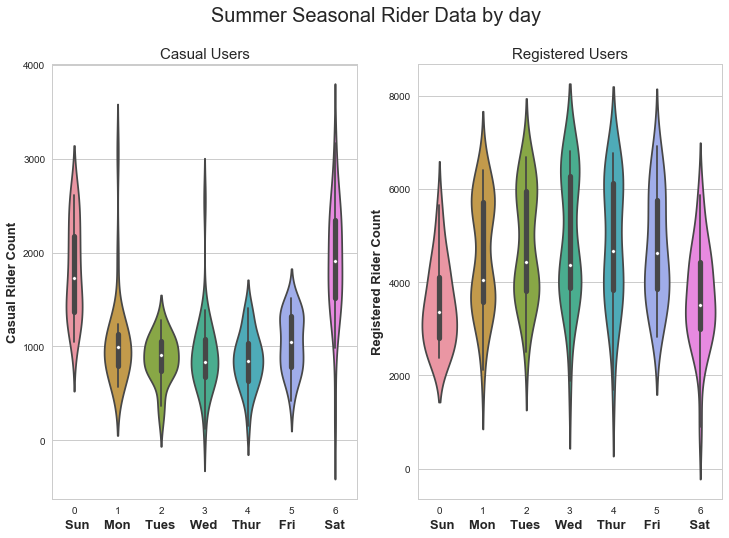

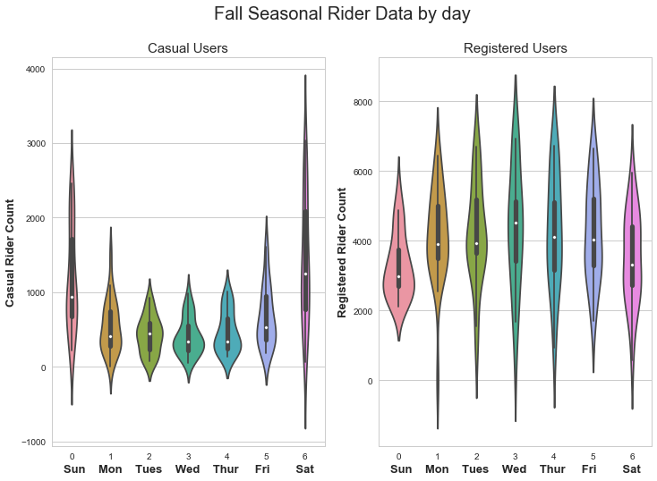

```python
# 1 = winter, 2 = spring, 3 = summer, 4 = fall


season1 = bikes_by_day[(bikes_by_day['season'] == 1)]
season2 = bikes_by_day[(bikes_by_day['season'] == 2)]
season3 = bikes_by_day[(bikes_by_day['season'] == 3)]
season4 = bikes_by_day[(bikes_by_day['season'] == 4)]

fig, ax = plt.subplots(1, 2, figsize=(12,8))
a = sns.violinplot(x="weekday", y="casual", data=season1, ax=ax[0])
b = sns.violinplot(x="weekday", y="registered", data=season1, ax=ax[1])
ax[0].set_title('Casual Users', fontsize=15)
ax[1].set_title('Registered Users', fontsize=15)
fig.suptitle('Winter Seasonal Rider Data by day', fontsize=20);
a.set_xlabel('Sun    Mon    Tues    Wed    Thur     Fri        Sat', fontsize=13, fontweight='bold')
a.set_ylabel('Casual Rider Count', fontsize=13, fontweight='bold')
b.set_ylabel('Registered Rider Count', fontsize=13, fontweight='bold')
b.set_xlabel('Sun    Mon    Tues    Wed    Thur     Fri        Sat', fontsize=13, fontweight='bold')
fig.show()

fig, ax = plt.subplots(1, 2, figsize=(12,8))
a = sns.violinplot(x="weekday", y="casual", data=season2, ax=ax[0])
b = sns.violinplot(x="weekday", y="registered", data=season2, ax=ax[1])
ax[0].set_title('Casual Users', fontsize=15)
ax[1].set_title('Registered Users', fontsize=15)
fig.suptitle('Spring Seasonal Rider Data by day', fontsize=20);
a.set_xlabel('Sun    Mon    Tues    Wed    Thur     Fri        Sat', fontsize=13, fontweight='bold')
a.set_ylabel('Casual Rider Count', fontsize=13, fontweight='bold')
b.set_ylabel('Registered Rider Count', fontsize=13, fontweight='bold')
b.set_xlabel('Sun    Mon    Tues    Wed    Thur     Fri        Sat', fontsize=13, fontweight='bold')
fig.show()

fig, ax = plt.subplots(1, 2, figsize=(12,8))
a = sns.violinplot(x="weekday", y="casual", data=season3, ax=ax[0])
b = sns.violinplot(x="weekday", y="registered", data=season3, ax=ax[1])
ax[0].set_title('Casual Users', fontsize=15)
ax[1].set_title('Registered Users', fontsize=15)
fig.suptitle('Summer Seasonal Rider Data by day', fontsize=20);
a.set_xlabel('Sun    Mon    Tues    Wed    Thur     Fri        Sat', fontsize=13, fontweight='bold')
a.set_ylabel('Casual Rider Count', fontsize=13, fontweight='bold')
b.set_ylabel('Registered Rider Count', fontsize=13, fontweight='bold')
b.set_xlabel('Sun    Mon    Tues    Wed    Thur     Fri        Sat', fontsize=13, fontweight='bold')
fig.show()

fig, ax = plt.subplots(1, 2, figsize=(12,8))
a = sns.violinplot(x="weekday", y="casual", data=season4, ax=ax[0])
b = sns.violinplot(x="weekday", y="registered", data=season4, ax=ax[1])
ax[0].set_title('Casual Users', fontsize=15)
ax[1].set_title('Registered Users', fontsize=15)
fig.suptitle('Fall Seasonal Rider Data by day', fontsize=20);
a.set_xlabel('Sun    Mon    Tues    Wed    Thur     Fri        Sat', fontsize=13, fontweight='bold')
a.set_ylabel('Casual Rider Count', fontsize=13, fontweight='bold')
b.set_ylabel('Registered Rider Count', fontsize=13, fontweight='bold')
b.set_xlabel('Sun    Mon    Tues    Wed    Thur     Fri        Sat', fontsize=13, fontweight='bold')
fig.show()
```

**Question 3: Prepare the data for Regression**

**3.1** Visualize and describe inter-dependencies among the following variables: `weekday`, `season`, `month`,`weather`, `temp`, `atemp`, `hum`, `windspeed`, `casual`,`registered`, `counts`. Note and comment on any strongly related variables.

**3.2** Convert the categorical attributes into multiple binary attributes using **one-hot encoding**.

**3.3** Split the initial `bikes_df` dataset (with hourly data about rentals) into train and test sets. Do this in a 'stratified' fashion, ensuring that all months are equally represented in each set. Explain your choice for a splitting algorithm. We ask you to create your train and test sets, but for consistency and easy checking we ask that, for the rest of this problem set, you use the train and test set provided in the question below.

**3.4** Read `data/BSS_train.csv` and `data/BSS_test.csv` into dataframes `BSS_train` and `BSS_test`, respectively. After checking your train and test datasets for accuracy, remove the `dteday` column from both train and test dataset. We do not need it, and its format cannot be used for analysis. Also, remove any predictors that would make predicting the `count` trivial.

**3.5** Calculate the **Pearson correlation** coefficients between all the features. Visualize the matrix using a heatmap. Which predictors have a positive correlation with the number of bike rentals? For categorical attributes, you should use each binary predictor resulting from one-hot encoding to compute their correlations. Identify pairs of predictors with collinearity >0.7.

#### Hints:

- You may use the `np.corrcoef` function to compute the correlation matrix for a data set (do not forget to transpose the data matrix). You may use `plt.pcolor` function to visualize the correlation matrix.

#### 3.1 Visualize and describe inter-dependencies ...

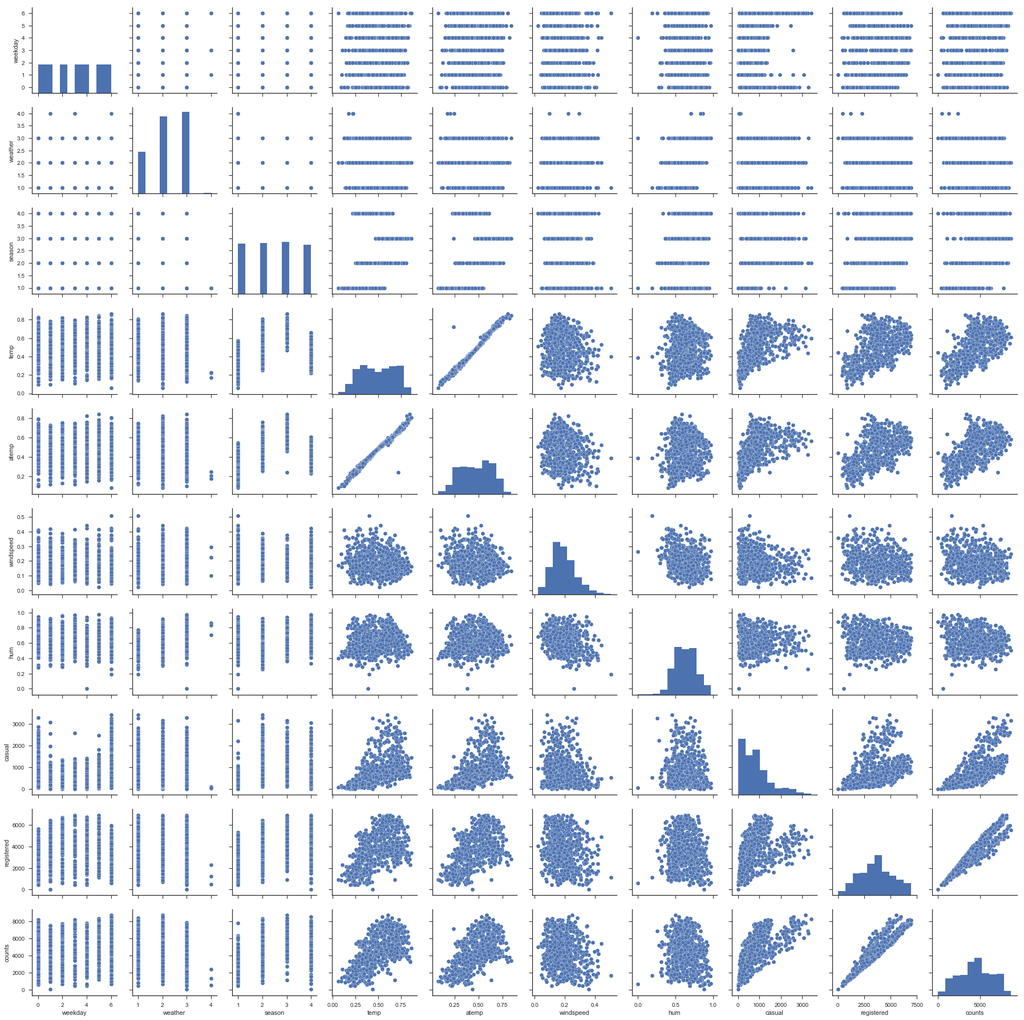

```python
sns.set(style="ticks")
df = bikes_by_day
sns.pairplot(df)
```

**Strongly related variables**

- temp and atemp: this is straight forward. They are directly related to each other
- registered/casual and counts: they are directly related to each other. We need the registered variable to do counts
- casual/registered and temp/atemp: as temp goes up, the number of rides goes up
- We don't see any linear correlation between the weekday/weather/season to casual/registered.

#### 3.2 Convert the categorical attributes ....

```python
#categorical attributes = weekday, weather, season

df_hot = bikes_by_day.copy()

one = pd.get_dummies(df_hot.weekday, prefix='weather').iloc[:, 1:]

two = pd.get_dummies(df_hot.weekday, prefix='weekday').iloc[:, 1:]

three = pd.get_dummies(df_hot.season, prefix='season').iloc[:, 1:]

# add them to data frame
df_hot = pd.concat([df_hot, one, two, three], axis = 1)

# resource used: https://www.youtube.com/watch?v=0s_1IsROgDc

df_hot.head()
```

|  | dteday | weekday | weather | season | temp | atemp | windspeed | hum | casual | registered | ... | weather_6 | weekday_1 | weekday_2 | weekday_3 | weekday_4 | weekday_5 | weekday_6 | season_2 | season_3 | season_4 |
| --- | --- | --- | --- | --- | --- | --- | --- | --- | --- | --- | --- | --- | --- | --- | --- | --- | --- | --- | --- | --- | --- |
| 0 | 2011-01-01 | 6 | 3 | 1 | 0.344167 | 0.363625 | 0.160446 | 0.805833 | 331 | 654 | ... | 1 | 0 | 0 | 0 | 0 | 0 | 1 | 0 | 0 | 0 |
| 1 | 2011-01-02 | 0 | 3 | 1 | 0.363478 | 0.353739 | 0.248539 | 0.696087 | 131 | 670 | ... | 0 | 0 | 0 | 0 | 0 | 0 | 0 | 0 | 0 | 0 |
| 2 | 2011-01-03 | 1 | 1 | 1 | 0.196364 | 0.189405 | 0.248309 | 0.437273 | 120 | 1229 | ... | 0 | 1 | 0 | 0 | 0 | 0 | 0 | 0 | 0 | 0 |
| 3 | 2011-01-04 | 2 | 2 | 1 | 0.200000 | 0.212122 | 0.160296 | 0.590435 | 108 | 1454 | ... | 0 | 0 | 1 | 0 | 0 | 0 | 0 | 0 | 0 | 0 |
| 4 | 2011-01-05 | 3 | 1 | 1 | 0.226957 | 0.229270 | 0.186900 | 0.436957 | 82 | 1518 | ... | 0 | 0 | 0 | 1 | 0 | 0 | 0 | 0 | 0 | 0 |

5 rows × 26 columns

pd head above shows one-hot encoding

#### 3.3 ....

```python
traindf, testdf = train_test_split(bikes_df,
                                   stratify = pd.to_datetime(bikes_df.index).month)

print(traindf.shape, testdf.shape)

# resource used: https://stackoverflow.com/questions/29438265/stratified-train-test-split-in-scikit-learn
# and http://scikit-learn.org/stable/modules/generated/sklearn.model_selection.train_test_split.html
```

```
(13034, 15) (4345, 15)
```

#### 3.4 Read `data/BSS_train.csv` and `data/BSS_test.csv` into ...

```python
BBS_train = pd.read_csv("data/BSS_train.csv", index_col=0)
BBS_train = BBS_train.drop('dteday', axis=1)
BBS_train = BBS_train.drop('casual', axis=1)
BBS_train = BBS_train.drop('registered', axis=1)

BBS_test = pd.read_csv("data/BSS_test.csv", index_col=0)
BBS_test = BBS_test.drop('dteday', axis=1)
BBS_test = BBS_test.drop('casual', axis=1)
BBS_test = BBS_test.drop('registered', axis=1)

BBS_train.head()
```

|  | hour | holiday | year | workingday | temp | atemp | hum | windspeed | counts | spring | ... | Dec | Mon | Tue | Wed | Thu | Fri | Sat | Cloudy | Snow | Storm |
| --- | --- | --- | --- | --- | --- | --- | --- | --- | --- | --- | --- | --- | --- | --- | --- | --- | --- | --- | --- | --- | --- |
| 0 | 0 | 0 | 0 | 0 | 0.24 | 0.2879 | 0.81 | 0.0 | 16 | 0 | ... | 0 | 0 | 0 | 0 | 0 | 0 | 1 | 0 | 0 | 0 |
| 1 | 1 | 0 | 0 | 0 | 0.22 | 0.2727 | 0.80 | 0.0 | 40 | 0 | ... | 0 | 0 | 0 | 0 | 0 | 0 | 1 | 0 | 0 | 0 |
| 2 | 2 | 0 | 0 | 0 | 0.22 | 0.2727 | 0.80 | 0.0 | 32 | 0 | ... | 0 | 0 | 0 | 0 | 0 | 0 | 1 | 0 | 0 | 0 |
| 3 | 3 | 0 | 0 | 0 | 0.24 | 0.2879 | 0.75 | 0.0 | 13 | 0 | ... | 0 | 0 | 0 | 0 | 0 | 0 | 1 | 0 | 0 | 0 |
| 4 | 4 | 0 | 0 | 0 | 0.24 | 0.2879 | 0.75 | 0.0 | 1 | 0 | ... | 0 | 0 | 0 | 0 | 0 | 0 | 1 | 0 | 0 | 0 |

5 rows × 32 columns

```python
BBS_test.head()
```

|  | hour | holiday | year | workingday | temp | atemp | hum | windspeed | counts | spring | ... | Dec | Mon | Tue | Wed | Thu | Fri | Sat | Cloudy | Snow | Storm |
| --- | --- | --- | --- | --- | --- | --- | --- | --- | --- | --- | --- | --- | --- | --- | --- | --- | --- | --- | --- | --- | --- |
| 6 | 6 | 0 | 0 | 0 | 0.22 | 0.2727 | 0.80 | 0.0000 | 2 | 0 | ... | 0 | 0 | 0 | 0 | 0 | 0 | 1 | 0 | 0 | 0 |
| 9 | 9 | 0 | 0 | 0 | 0.32 | 0.3485 | 0.76 | 0.0000 | 14 | 0 | ... | 0 | 0 | 0 | 0 | 0 | 0 | 1 | 0 | 0 | 0 |
| 20 | 20 | 0 | 0 | 0 | 0.40 | 0.4091 | 0.87 | 0.2537 | 36 | 0 | ... | 0 | 0 | 0 | 0 | 0 | 0 | 1 | 1 | 0 | 0 |
| 33 | 10 | 0 | 0 | 0 | 0.36 | 0.3485 | 0.81 | 0.2239 | 53 | 0 | ... | 0 | 0 | 0 | 0 | 0 | 0 | 0 | 1 | 0 | 0 |
| 35 | 12 | 0 | 0 | 0 | 0.36 | 0.3333 | 0.66 | 0.2985 | 93 | 0 | ... | 0 | 0 | 0 | 0 | 0 | 0 | 0 | 1 | 0 | 0 |

5 rows × 32 columns

Displaying the head of the pd frames shows that the columns needed to be dropped were dropped out.

#### 3.5 Calculate the **Pearson correlation** ....

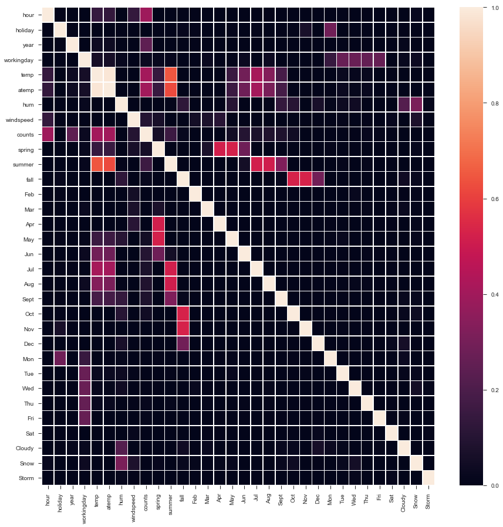

```python
pearson = BBS_train.corr(method='pearson')

fig, ax = plt.subplots(figsize=(15,15))
sns.heatmap(pearson, vmin=0, vmax=1, linewidths=.5)


# resource: https://pandas.pydata.org/pandas-docs/stable/generated/pandas.DataFrame.corr.html
# also used: https://seaborn.pydata.org/generated/seaborn.heatmap.html
```

```python
print(pearson)
```

[output not shown]

[output cut: 82 more lines]

[output not shown]

From looking at the heatmap, with the number of bike rentals, the predictors that have a positive correlation are: hour, temp, atemp, and year.

**Question 4: Multiple Linear Regression**

**4.1** Use statsmodels to fit a multiple linear regression model to the training set using all the predictors (no interactions or polynomial terms), and report its $R^2$ score on the train and test sets.

**4.2** Find out which of estimated coefficients are statistically significant at a significance level of 5% (p-value < 0.05). Comment on the results.

**4.3** Make a plot of residuals of the fitted model ${e} = y - \hat{y}$ as a function of the predicted value $\hat{y}$. Note that this is slightly different from the residual plot for simple linear regression. Draw a horizontal line denoting the zero residual value on the Y-axis. Does the plot reveal a non-linear relationship between the predictors and response? What does the plot convey about the variance of the error terms?

### Answers

#### 4.1 Use statsmodels to fit a ...

```python
X = BBS_train[['hour', 'holiday', 'year', 'workingday', 'temp', 'atemp', 'hum','spring', 'summer', 'fall',
              'Feb', 'Mar', 'Apr', 'May','Jun', 'Jul', 'Aug', 'Sept', 'Oct', 'Nov', 'Dec', 'Mon', 'Tue', 'Wed',
              'Thu', 'Fri', 'Sat', 'Cloudy', 'Snow', 'Storm']]

y = BBS_train['counts']

X = sm.add_constant(X)
model = sm.OLS(y, X).fit()


test_x = BBS_test[['hour', 'holiday', 'year', 'workingday', 'temp', 'atemp', 'hum','spring', 'summer', 'fall',
              'Feb', 'Mar', 'Apr', 'May','Jun', 'Jul', 'Aug', 'Sept', 'Oct', 'Nov', 'Dec', 'Mon', 'Tue', 'Wed',
              'Thu', 'Fri', 'Sat', 'Cloudy', 'Snow', 'Storm']]
test_y = BBS_test['counts']

r2_test = r2_score(test_y, model.predict(sm.add_constant(test_x)))

print('R2 for train set:', model.rsquared)
print('R2 for test model:', r2_test)

# resource: https://blog.datarobot.com/multiple-regression-using-statsmodels
```

```
R2 for train set: 0.40635120125670743
R2 for test model: 0.40595089350757974
```

#### 4.2 Find out which of estimated coefficients ...

```python
# report coefficients that have p value < 0.05

model.summary()
```

OLS Regression Results

| Dep. Variable: | counts | R-squared: | 0.406 |
| --- | --- | --- | --- |
| Model: | OLS | Adj. R-squared: | 0.405 |
| Method: | Least Squares | F-statistic: | 327.4 |
| Date: | Wed, 18 Jul 2018 | Prob (F-statistic): | 0.00 |
| Time: | 22:28:12 | Log-Likelihood: | -88308. |
| No. Observations: | 13903 | AIC: | 1.767e+05 |
| Df Residuals: | 13873 | BIC: | 1.769e+05 |
| Df Model: | 29 |  |  |
| Covariance Type: | nonrobust |  |  |

|  | coef | std err | t | P>\|t\| | [0.025 | 0.975] |
| --- | --- | --- | --- | --- | --- | --- |
| const | -14.0773 | 7.968 | -1.767 | 0.077 | -29.695 | 1.541 |
| hour | 7.2341 | 0.184 | 39.229 | 0.000 | 6.873 | 7.596 |
| holiday | -18.4174 | 6.596 | -2.792 | 0.005 | -31.346 | -5.488 |
| year | 76.1531 | 2.378 | 32.022 | 0.000 | 71.492 | 80.815 |
| workingday | 11.3008 | 2.751 | 4.108 | 0.000 | 5.908 | 16.693 |
| temp | 356.4330 | 42.757 | 8.336 | 0.000 | 272.624 | 440.242 |
| atemp | 51.1617 | 44.832 | 1.141 | 0.254 | -36.715 | 139.039 |
| hum | -209.4844 | 7.566 | -27.689 | 0.000 | -224.314 | -194.655 |
| spring | 43.1702 | 7.418 | 5.820 | 0.000 | 28.630 | 57.711 |
| summer | 29.2452 | 8.773 | 3.333 | 0.001 | 12.049 | 46.442 |
| fall | 67.6397 | 7.479 | 9.045 | 0.000 | 52.981 | 82.299 |
| Feb | -7.6642 | 5.966 | -1.285 | 0.199 | -19.359 | 4.031 |
| Mar | -11.6669 | 6.666 | -1.750 | 0.080 | -24.732 | 1.399 |
| Apr | -41.2879 | 9.878 | -4.180 | 0.000 | -60.651 | -21.925 |
| May | -34.1679 | 10.536 | -3.243 | 0.001 | -54.819 | -13.516 |
| Jun | -67.2084 | 10.697 | -6.283 | 0.000 | -88.175 | -46.242 |
| Jul | -95.1258 | 12.062 | -7.886 | 0.000 | -118.770 | -71.482 |
| Aug | -60.6874 | 11.813 | -5.138 | 0.000 | -83.842 | -37.533 |
| Sept | -16.8872 | 10.568 | -1.598 | 0.110 | -37.603 | 3.828 |
| Oct | -16.0654 | 9.866 | -1.628 | 0.103 | -35.405 | 3.274 |
| Nov | -25.3482 | 9.525 | -2.661 | 0.008 | -44.018 | -6.678 |
| Dec | -9.9804 | 7.614 | -1.311 | 0.190 | -24.904 | 4.943 |
| Mon | -2.6003 | 2.978 | -0.873 | 0.383 | -8.438 | 3.238 |
| Tue | -6.0797 | 3.208 | -1.895 | 0.058 | -12.367 | 0.208 |
| Wed | 2.1858 | 3.183 | 0.687 | 0.492 | -4.053 | 8.425 |
| Thu | -3.2486 | 3.185 | -1.020 | 0.308 | -9.492 | 2.995 |
| Fri | 2.6262 | 3.184 | 0.825 | 0.409 | -3.614 | 8.866 |
| Sat | 14.9864 | 4.382 | 3.420 | 0.001 | 6.397 | 23.576 |
| Cloudy | 7.0039 | 2.898 | 2.417 | 0.016 | 1.323 | 12.685 |
| Snow | -26.7320 | 4.762 | -5.614 | 0.000 | -36.066 | -17.398 |
| Storm | 44.5767 | 98.383 | 0.453 | 0.650 | -148.268 | 237.421 |

| Omnibus: | 2832.667 | Durbin-Watson: | 0.756 |
| --- | --- | --- | --- |
| Prob(Omnibus): | 0.000 | Jarque-Bera (JB): | 5661.391 |
| Skew: | 1.224 | Prob(JB): | 0.00 |
| Kurtosis: | 4.943 | Cond. No. | 1.17e+16 |

Warnings:  
[1] Standard Errors assume that the covariance matrix of the errors is correctly specified.  
[2] The smallest eigenvalue is 1.87e-26. This might indicate that there are  
strong multicollinearity problems or that the design matrix is singular.

```python
model.pvalues < 0.05
```

```
const         False
hour           True
holiday        True
year           True
workingday     True
temp           True
atemp         False
hum            True
spring         True
summer         True
fall           True
Feb           False
Mar           False
Apr            True
May            True
Jun            True
Jul            True
Aug            True
Sept          False
Oct           False
Nov            True
Dec           False
Mon           False
Tue           False
Wed           False
Thu           False
Fri           False
Sat            True
Cloudy         True
Snow           True
Storm         False
dtype: bool
```

## resource: https://measuringu.com/statistically-significant/

#### 4.3 Make a plot of residuals of the fitted ...

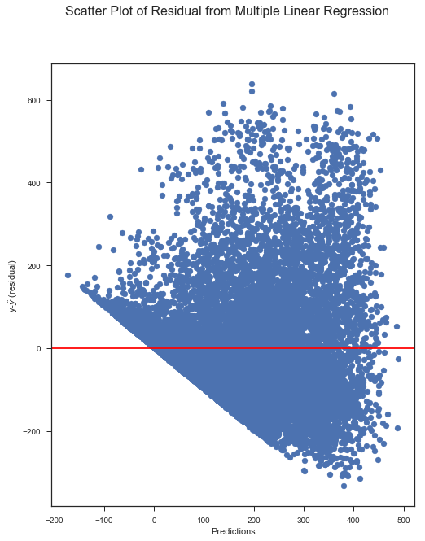

```python
# e- y_true - y_pred

y_true = y
y_pred = model.predict()

residual = (y_true - y_pred)

fig, ax = plt.subplots(1,1, figsize=(8,10))
ax.scatter(y_pred, residual, label="training data")
plt.axhline(0, color='red')
ax.set_xlabel('Predictions')
ax.set_ylabel('y-$\hat{y}$ (residual)')
fig.suptitle('Scatter Plot of Residual from Multiple Linear Regression', fontsize=16);
```

The residual plot sort of shows a negative linear relationship between the predictors and response because it is decreasing as the predictions increase. On the topic of the variance of error terms, the plot is showing a tendency to predict negatively as the predictions increase. It is more accuarate as the predictions get smaller.

**Question 5: Subset Selection**

**5.1** Implement forward step-wise selection to select a minimal subset of predictors that are related to the response variable:

We require that you implement the method **from scratch**. You may use the Bayesian Information Criterion (BIC) to choose the subset size in each method.

**5.2** Do these methods eliminate one or more of the colinear predictors (if any) identified in Question 3.5? If so, which ones. Briefly explain (3 or fewer sentences) why you think this may be the case.

**5.3** Fit the linear regression model using the identified subset of predictors to the training set. How do the test $R^2$ scores for the fitted models compare with the model fitted in Question 4 using all predictors?

### Answers

#### 5.1 Implement forward step-wise ....

```python
# added one by one to subset x to find the best combination. only add if pvalue < 0.05

subset_x = BBS_train[['hour', 'holiday', 'year', 'workingday', 'temp', 'hum', 'spring', 'summer', 'fall',
                     'Apr', 'May', 'Jun', 'Jul', 'Aug', 'Nov', 'Sat', 'Cloudy', 'Snow']]

# did not add 12 of them, if R2 decreased after adding, dropped from list

subset_y = BBS_train['counts']

# resource: http://www.biostat.jhsph.edu/~iruczins/teaching/jf/ch10.pdf
```

Implemented it one by one. I went through and tried to add more predictors into the subset_x and then calcaulte it. This was using forward step-wise selection one by one, and I came up with this combination of predictors.

#### 5.3 In each case, fit linear regression ...

```python
X = sm.add_constant(subset_x)
sub = sm.OLS(subset_y, X).fit()

sub.summary()
```

OLS Regression Results

| Dep. Variable: | counts | R-squared: | 0.406 |
| --- | --- | --- | --- |
| Model: | OLS | Adj. R-squared: | 0.405 |
| Method: | Least Squares | F-statistic: | 526.9 |
| Date: | Wed, 18 Jul 2018 | Prob (F-statistic): | 0.00 |
| Time: | 22:42:14 | Log-Likelihood: | -88314. |
| No. Observations: | 13903 | AIC: | 1.767e+05 |
| Df Residuals: | 13884 | BIC: | 1.768e+05 |
| Df Model: | 18 |  |  |
| Covariance Type: | nonrobust |  |  |

|  | coef | std err | t | P>\|t\| | [0.025 | 0.975] |
| --- | --- | --- | --- | --- | --- | --- |
| const | -15.9596 | 7.302 | -2.186 | 0.029 | -30.272 | -1.647 |
| hour | 7.2706 | 0.183 | 39.681 | 0.000 | 6.911 | 7.630 |
| holiday | -20.4296 | 7.596 | -2.689 | 0.007 | -35.319 | -5.540 |
| year | 76.3896 | 2.375 | 32.163 | 0.000 | 71.734 | 81.045 |
| workingday | 9.9561 | 3.422 | 2.909 | 0.004 | 3.248 | 16.664 |
| temp | 391.6092 | 11.640 | 33.642 | 0.000 | 368.792 | 414.426 |
| hum | -209.6542 | 7.390 | -28.370 | 0.000 | -224.140 | -195.169 |
| spring | 37.9566 | 6.385 | 5.945 | 0.000 | 25.442 | 50.471 |
| summer | 22.3995 | 6.216 | 3.603 | 0.000 | 10.215 | 34.584 |
| fall | 61.6811 | 4.295 | 14.361 | 0.000 | 53.262 | 70.100 |
| Apr | -27.7004 | 6.969 | -3.975 | 0.000 | -41.361 | -14.040 |
| May | -19.6031 | 7.128 | -2.750 | 0.006 | -33.574 | -5.632 |
| Jun | -51.3459 | 6.397 | -8.026 | 0.000 | -63.886 | -38.806 |
| Jul | -77.4199 | 6.258 | -12.370 | 0.000 | -89.687 | -65.152 |
| Aug | -43.9252 | 6.126 | -7.171 | 0.000 | -55.933 | -31.918 |
| Nov | -12.0988 | 5.174 | -2.338 | 0.019 | -22.240 | -1.957 |
| Sat | 14.8292 | 4.379 | 3.387 | 0.001 | 6.246 | 23.412 |
| Cloudy | 7.0353 | 2.887 | 2.437 | 0.015 | 1.376 | 12.694 |
| Snow | -27.1796 | 4.732 | -5.744 | 0.000 | -36.455 | -17.904 |

| Omnibus: | 2809.628 | Durbin-Watson: | 0.755 |
| --- | --- | --- | --- |
| Prob(Omnibus): | 0.000 | Jarque-Bera (JB): | 5577.654 |
| Skew: | 1.218 | Prob(JB): | 0.00 |
| Kurtosis: | 4.921 | Cond. No. | 159. |

Warnings:  
[1] Standard Errors assume that the covariance matrix of the errors is correctly specified.

```python
print('R2 from step-forward selection for train set:', sub.rsquared)
print('R2 for train set from Q4:', model.rsquared)
```

```
R2 from step-forward selection for train set: 0.40587568903028415
R2 for train set from Q4: 0.40635120125670743
```

R2 from this question's method is similar.

**Question 6: Polynomial Regression**

We will now try to improve the performance of the regression model by including higher-order polynomial terms.

**6.1** For each continuous predictor $X_j$, include additional polynomial terms $X^2_j$, $X^3_j$, and $X^4_j$, and fit a polynomial regression model to the expanded training set. How does the $R^2$ of this model on the test set compare with that of the linear model fitted in the previous question? Using a $t$-tests, find out which of the estimated coefficients for the polynomial terms are statistically significant at a significance level of 5%.

```python
# cts predictors = numeric variables that have infinite # of values in any bounded interval
# predictors used: temp, atemp, hum, year, hour. All others do not fit the defiintion of a cts predictor

y_train = BBS_train['counts']
y_test = BBS_test['counts']
x_train = BBS_train[['temp', 'atemp', 'hum', 'year', 'hour', ]]
x_test = BBS_test[['temp', 'atemp', 'hum', 'year','hour']]

# Have to transform to 4th degree for every term

transform = PolynomialFeatures(degree=4)
new_features = transform.fit_transform(x_train)

x_reg = sm.add_constant(new_features)
polymodel = sm.OLS(y_train, x_reg).fit()

polymodel.summary()
```

OLS Regression Results

| Dep. Variable: | counts | R-squared: | 0.599 |
| --- | --- | --- | --- |
| Model: | OLS | Adj. R-squared: | 0.596 |
| Method: | Least Squares | F-statistic: | 198.0 |
| Date: | Wed, 18 Jul 2018 | Prob (F-statistic): | 0.00 |
| Time: | 22:42:50 | Log-Likelihood: | -85584. |
| No. Observations: | 13903 | AIC: | 1.714e+05 |
| Df Residuals: | 13798 | BIC: | 1.722e+05 |
| Df Model: | 104 |  |  |
| Covariance Type: | nonrobust |  |  |

|  | coef | std err | t | P>\|t\| | [0.025 | 0.975] |
| --- | --- | --- | --- | --- | --- | --- |
| const | 194.4786 | 192.397 | 1.011 | 0.312 | -182.646 | 571.603 |
| x1 | -5379.5635 | 3000.204 | -1.793 | 0.073 | -1.13e+04 | 501.244 |
| x2 | 5447.2103 | 3069.617 | 1.775 | 0.076 | -569.656 | 1.15e+04 |
| x3 | -730.6966 | 791.054 | -0.924 | 0.356 | -2281.269 | 819.876 |
| x4 | -25.3176 | 36.312 | -0.697 | 0.486 | -96.494 | 45.858 |
| x5 | -55.9071 | 14.504 | -3.855 | 0.000 | -84.337 | -27.477 |
| x6 | 1.495e+04 | 1.91e+04 | 0.781 | 0.435 | -2.25e+04 | 5.24e+04 |
| x7 | -3.097e+04 | 4.06e+04 | -0.762 | 0.446 | -1.11e+05 | 4.86e+04 |
| x8 | 2.162e+04 | 9660.473 | 2.238 | 0.025 | 2685.029 | 4.06e+04 |
| x9 | -262.7620 | 659.262 | -0.399 | 0.690 | -1555.006 | 1029.481 |
| x10 | 242.9517 | 175.177 | 1.387 | 0.165 | -100.419 | 586.323 |
| x11 | 1.523e+04 | 2.24e+04 | 0.680 | 0.497 | -2.87e+04 | 5.92e+04 |
| x12 | -2.061e+04 | 1e+04 | -2.053 | 0.040 | -4.03e+04 | -933.292 |
| x13 | 261.4639 | 687.532 | 0.380 | 0.704 | -1086.193 | 1609.120 |
| x14 | -339.7512 | 181.278 | -1.874 | 0.061 | -695.080 | 15.578 |
| x15 | 794.9902 | 1300.806 | 0.611 | 0.541 | -1754.767 | 3344.747 |
| x16 | 161.4201 | 163.480 | 0.987 | 0.323 | -159.024 | 481.864 |
| x17 | 174.0084 | 35.696 | 4.875 | 0.000 | 104.039 | 243.977 |
| x18 | -26.3682 | 36.337 | -0.726 | 0.468 | -97.594 | 44.858 |
| x19 | -3.1522 | 2.761 | -1.141 | 0.254 | -8.565 | 2.261 |
| x20 | 5.2414 | 0.997 | 5.259 | 0.000 | 3.288 | 7.195 |
| x21 | -1.41e+05 | 8.38e+04 | -1.683 | 0.092 | -3.05e+05 | 2.32e+04 |
| x22 | 4.406e+05 | 2.8e+05 | 1.574 | 0.116 | -1.08e+05 | 9.89e+05 |
| x23 | -7.109e+04 | 3.15e+04 | -2.257 | 0.024 | -1.33e+05 | -9356.653 |
| x24 | 2969.7000 | 7041.333 | 0.422 | 0.673 | -1.08e+04 | 1.68e+04 |
| x25 | 130.8530 | 652.895 | 0.200 | 0.841 | -1148.910 | 1410.616 |
| x26 | -4.382e+05 | 3.19e+05 | -1.374 | 0.169 | -1.06e+06 | 1.87e+05 |
| x27 | 1.271e+05 | 6.72e+04 | 1.891 | 0.059 | -4633.011 | 2.59e+05 |
| x28 | -5861.6714 | 1.51e+04 | -0.388 | 0.698 | -3.55e+04 | 2.38e+04 |
| x29 | -274.1814 | 1372.278 | -0.200 | 0.842 | -2964.034 | 2415.671 |

[output cut: 96 more lines]

| Omnibus: | 3489.942 | Durbin-Watson: | 0.935 |
| --- | --- | --- | --- |
| Prob(Omnibus): | 0.000 | Jarque-Bera (JB): | 10113.866 |
| Skew: | 1.312 | Prob(JB): | 0.00 |
| Kurtosis: | 6.251 | Cond. No. | 1.25e+16 |

Warnings:  
[1] Standard Errors assume that the covariance matrix of the errors is correctly specified.  
[2] The smallest eigenvalue is 9.15e-19. This might indicate that there are  
strong multicollinearity problems or that the design matrix is singular.

```python
print('R2 value:', polymodel.rsquared)
```

```
R2 value: 0.5988251844985915
```

```python
print(polymodel.params)
```

```
const       194.478590
x1        -5379.563481
x2         5447.210291
x3         -730.696575
x4          -25.317642
x5          -55.907054
x6        14947.579485
x7       -30966.590859
x8        21620.869413
x9         -262.762042
x10         242.951699
x11       15234.919204
x12      -20606.345455
x13         261.463927
x14        -339.751207
x15         794.990213
x16         161.420080
x17         174.008405
x18         -26.368153
x19          -3.152224
x20           5.241419
x21     -141032.071057
x22      440600.388662
x23      -71087.300917
x24        2969.700031
x25         130.852976
x26     -438197.914257
x27      127130.421726
x28       -5861.671415
x29        -274.181362
             ...
x96       -6993.397181
x97        -172.956566
x98        3239.395244
x99          16.955460
x100        -17.003225
x101      -6703.938565
x102       5145.450648
x103       -376.544717
x104      -1671.786906
x105        -17.222467
x106         -5.322175
x107        263.010046
x108         35.635514
x109         -2.289276
x110         -0.420578
x111        381.772487
x112       -282.714335
x113        -20.363841
x114       -138.769764
x115         10.855825
x116          5.069788
x117        160.315498
x118          1.759641
x119         -0.519068
x120          0.268017
x121        -26.371976
x122         -3.148576
x123          0.882827
x124         -0.058614
x125          0.001244
Length: 126, dtype: float64
```

This model's R2 is significantly higher, 0.59 vs 0.406.

# Written Report to the Administrators

**Question 7**

Write a short summary report, intended for the administrators of the company, to address two major points (can be written as two large paragraphs):

1. How to predict ridership well (which variables are important, when is ridership highest/lowest, etc.).
2. Suggestions on how to increase the system revenue (what additional services to provide, when to give discounts, etc.).

Include your report below. The report should not be longer than 300 words and should include a maximum of 3 figures.

### Answers

#### 7

Using all of the data in this report, I came up with two different scenarios that could increase system revenue. The first one would be to charge riders less at later times of the day, whether it is a registered or casual user. This might push them towards trying out the bikes. A second suggestion to increase ridership would be to implement surge pricing, similar to Uber. For example, increase prices during morning commute or afternoon commutes. On the other hand, during the off months, such as the Fall or winter days, lower the price below the regular rate to get people to use the bikes. The charts below show how the ridership decreased based on season and how there is a surge of users during morning commute times.

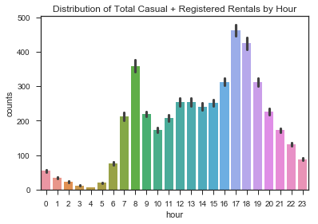

```python
plt.title("Distribution of Total Casual + Registered Rentals by Hour")
sns.set(style="whitegrid")
ax = sns.barplot(x="hour", y="counts", data=bikes_df)
```

[figure not shown]

```python
fig, ax = plt.subplots(figsize=(8,6))
a = sns.violinplot(x="season", y="counts", data=bikes_by_day)
fig.suptitle('Total Rider Data by Weather (by day)', fontsize=20);
a.set_xlabel(' Winter                  Summer              Spring                      Fall', fontsize=13, fontweight='bold')
a.set_ylabel('Total Rider Count', fontsize=13, fontweight='bold')
fig.show()
```